# Spatial Statistics in Epidemiology and Public Health - SISMID 2026

July 16, 2026

# 1 Mini Project Overview

In this lab session, we will work through the following key steps in conducting a spatial analysis.

1. Identify and acquire geospatial datasets.
2. Prepare spatial data objects in R.
3. Visualize the data with maps.
4. Perform exploratory data analysis.
5. Specify and fit regression models.
6. Summarize results.

Utilizing the skillsets we just learned, this lab session will focus on analyzing **county-level data**. You are encouraged to come up with a unique mini research question by identifying an outcome and a risk factor of interest using the datasets describe below. You may also choose to just follow along with the examples!

# 2 Finding Geospatial Datasets

**Suggested Time: 20 minutes**

1. **AtlasPlus** from the National Center for HIV, Viral Hepatitis, STD, and Tuberculosis Prevention.
   - Link: https://gis.cdc.gov/grasp/nchhstpatlas/maps.html
   - About: https://www.cdc.gov/nchhstp/about/atlasplus.html
2. **Data Explorer** from the National Environmental Public Heatlh Tracking Network
   - Link: https://ephtracking.cdc.gov/DataExplorer/
   - About: https://ephtracking.cdc.gov/indicatorPages

#### **Specific Tasks**

- Identify your research question by picking an outcome of interest and some covariates with data available at the county-level.
- Select a study region with at least 50 counties (e.g., a single state of a few contiguous states).
- Figure out how to download the data (typically in a .csv file format).
- Share in the Slack Channel about what research topic you have chosen!

This analysis aims to estimate associations between emergency department visits for asthma and particulate matter air pollution from diesel. We will utilize the 2019 annual county-level data from the National Environmental Public Health Tracking Network.The study region will include 4 states from the Mid-Atlantic and Northeast region (PA, MD, NY and NJ). We also obtained variables on the population size.

The downloaded datasets *asthmaED_2019.csv*, *diesel_2019.csv* and *population_2019.csv* are on the course website.

# 3 Data Wrangling

**Suggested Time: 20 minutes**

The first step is to construct an analytic data from the files we just downloaded. We will use the county 5-digit ID (FIPS Code) for linkage. Here are the issues we encountered and some potential other ones.

- Missing values are in given text “suppressed,” which we re-code to NA and convert the variable to numeric.
- Population size is stratified by age group, and we sum up all groups within each county.
- Some county FIPS ID has less than 5 digits because of missing leading zeros, which needs to be padded.

#### **Specific Tasks**

- Identify the variables needed from the downloaded datasets.
- Check issues related to missing data.
- Examine summary statistics of the variables and create some exploratory plots (boxplot, histogram, scatter plot).

```r
library (dplyr)
library (readr)
library (table1)

### Read in CSV files ###
asthma = read.csv ("Lab Example Data/asthmaED_2019.csv")
diesel = read.csv ("Lab Example Data/diesel_2019.csv")
pop = read.csv ("Lab Example Data/population_2019.csv")

### Rename variable
asthma =  rename (asthma, asthma = Value)
diesel = rename (diesel, diesel = Value)

#Replace suppressed values with NA
asthma = asthma %>%
  mutate (asthma = na_if (asthma, "Suppressed"))
asthma$asthma = parse_number(asthma$asthma)

#Aggregate age-group population to total population
pop$pop = parse_number(pop$Value)
pop_tot = pop %>%
  group_by (CountyFIPS) %>%
  summarize (pop_total = sum (pop))

# Subset to study states ###
dat = subset (asthma, State %in% c("Maryland", "Pennsylvania", "New York", "New Jersey") )
dat =  dat %>% select (State, CountyFIPS, County,  asthma)

# Merge data by CountyFIPS
dat = dat %>%
  left_join(diesel %>% select (CountyFIPS, diesel), by = join_by (CountyFIPS)) %>%
  left_join(pop_tot, by = join_by (CountyFIPS))

dat$rate = round(dat$asthma/dat$pop_total*10000 )

table1(~State + asthma+ diesel + pop_total + rate, data = dat)
```

|  | Overall (N=174) |
| --- | --- |
| State |  |
| Maryland | 24 (13.8%) |
| New Jersey | 21 (12.1%) |
| New York | 62 (35.6%) |
| Pennsylvania | 67 (38.5%) |
| asthma |  |
| Mean (SD) | 1510 (3880) |
| Median [Min, Max] | 332 [10.0, 30800] |
| Missing | 2 (1.1%) |
| diesel |  |
| Mean (SD) | 0.158 (0.159) |
| Median [Min, Max] | 0.110 [0.0300, 1.11] |
| pop_total |  |
| Mean (SD) | 271000 (398000) |
| Median [Min, Max] | 107000 [4420, 2560000] |
| rate |  |
| Mean (SD) | 37.0 (26.4) |
| Median [Min, Max] | 31.0 [2.00, 217] |
| Missing | 2 (1.1%) |

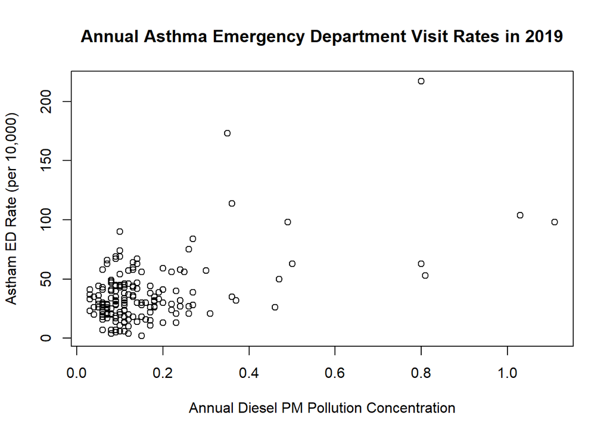

```r
plot (dat$rate~dat$diesel, xlab = "Annual Diesel PM Pollution Concentration", ylab = "Astham ED Rate (per 10,000)", main= "Annual Asthma Emergency Department Visit Rates in 2019")
```

# 4 Creating Geospatial Datasets and Mapping

**Suggested Time: 20 minutes**

For area-level data, we need to associate geospatial polygon information to each county. This is often included in a *shapefiles*. The US Census Bureau [publishes shapefiles](https://www.census.gov/geographies/mapping-files/time-series/geo/tiger-line-file.2024.html#list-tab-790442341) for various geographica units (e.g., county, tracts, ZCTA). Here we will use *tigris* package that downloads from the Census. Below is the code snippet for our example with 4 states.

```r
library (tigris)
options(tigris_use_cache = TRUE)

#option cb = TRUE to download the coarser version for speed
#we choose the year 2020
dat_sf <- counties(state = c("MD", "PA", "NY", "NJ"), cb = TRUE, year = 2020)
```

#### **Specific Tasks**

- Download the county shapefile for your study region.
- Create two county maps showing your outcome and exposure of interests. Share on Slack channel!

Note that the resulting dataset is an *sf* object. Geometry is recorded in latitude and longtidue (NAD83). The dataset already contains several variables. **GEOID** is the 5-digit FIPS code for linking to other datasets. Below are the first 3 rows of the download county shapefil dataset and its meta data. A quick map shows that we have acquired the correct shapefile!

```r
head (dat_sf, 3)
```

```
## Simple feature collection with 3 features and 12 fields
## Geometry type: MULTIPOLYGON
## Dimension:     XY
## Bounding box:  xmin: -75.42906 ymin: 39.51497 xmax: -74.20515 ymax: 40.75829
## Geodetic CRS:  NAD83
##    STATEFP COUNTYFP COUNTYNS       AFFGEOID GEOID       NAME          NAMELSAD
## 18      34      015 00882277 0500000US34015 34015 Gloucester Gloucester County
## 19      34      023 00882230 0500000US34023 34023  Middlesex  Middlesex County
## 20      34      035 00882234 0500000US34035 34035   Somerset   Somerset County
##    STUSPS STATE_NAME LSAD     ALAND   AWATER                       geometry
## 18     NJ New Jersey   06 833976887 38259771 MULTIPOLYGON (((-75.4283 39...
## 19     NJ New Jersey   06 800881307 35356734 MULTIPOLYGON (((-74.63023 4...
## 20     NJ New Jersey   06 781829190  7996119 MULTIPOLYGON (((-74.79619 4...
```

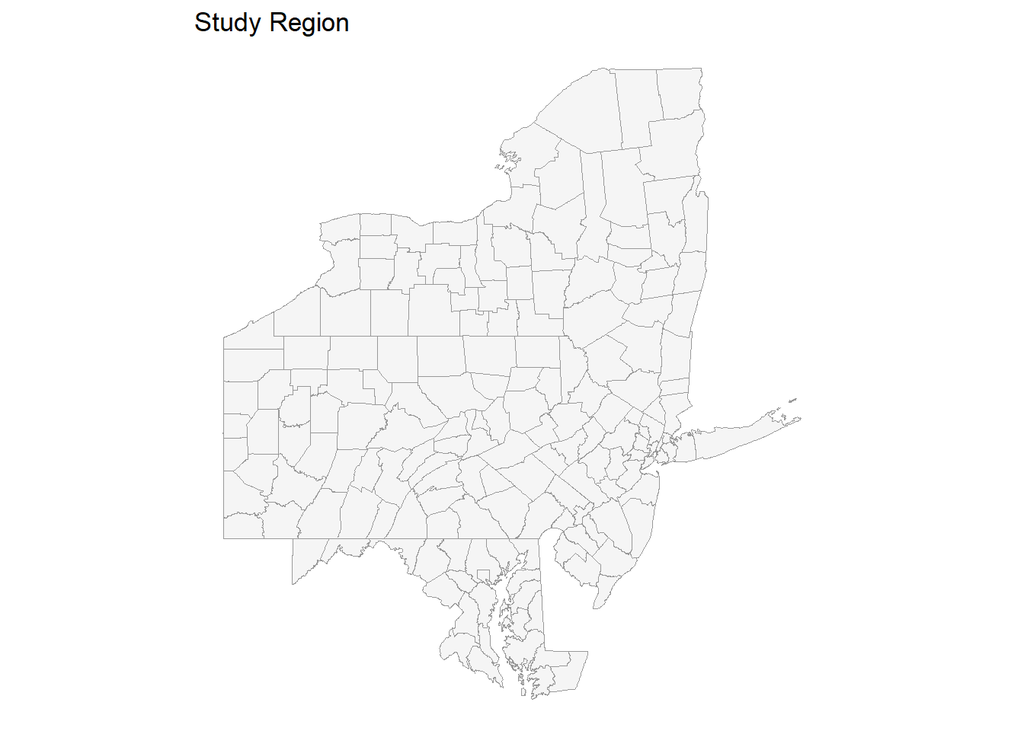

```r
library (ggplot2)
ggplot(data = dat_sf) +
  geom_sf(fill = "whitesmoke", color = "gray60", size = 0.1) +  theme_void() +
  labs(title = "Study Region")
```

Next, we merge our dataset with the county sf object, and create choropleth maps for the exposure and outcome. *dplyr* joint functions can work with *sf*. Note that two PA counties with missing ED data in grey.

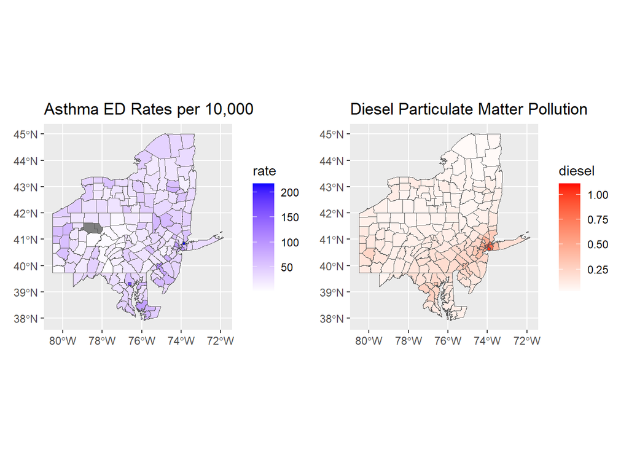

```r
library (patchwork)
dat$CountyFIPS = as.character (dat$CountyFIPS)
dat_sf = dat_sf %>% left_join (dat,  by = join_by (GEOID == CountyFIPS) )

g1 = ggplot(data = dat_sf) +
  geom_sf(aes(fill = rate)) +
  labs(title="Asthma ED Rates per 10,000")+scale_fill_gradient2(low = "white",high = "blue")

g2= ggplot(data = dat_sf) +
  geom_sf(aes(fill = diesel)) +
  labs(title="Diesel Particulate Matter Pollution")+scale_fill_gradient2(low = "white",high = "red")

g1+g2
```

# 5 Spatial Exploratory Analysis

**Suggested Time: 20 minutes**

Based the outcome, study region and maps from Section 4, what should we use as the neighbor/network structure to induce spatial correlation? The most commonly used one for county-level is to use whether two counties share a border.

#### **Specific Tasks**

- Construct an adjacency matrix for the analysis.
- Is there evidence of spatial auto-correlation in the outcome and covariates?

In our example, we define spatial neighbors using *either* the 1st-order adjacency (i.e., sharing a boundary) or two counties have centroids that are within 25 km. This is because some small counties counties do not share a border across rivers. We also drop the two counties with missing data.

```r
library (spdep)

#Drop missing data
dat_sf = subset (dat_sf, !is.na (dat_sf$rate))

#Project the data to, for example, the Lambert Conformal Conic North America.
dat_proj = st_transform(dat_sf, crs = "ESRI:102004")
center_proj = st_centroid(dat_proj)

#Create 1-st order adjacency and distance buffer (100km)
nb.1st = poly2nb (dat_proj)
nb.buffer = dnearneigh(center_proj, d1=0, d2 = 25*1000)
nb = union.nb (nb.1st, nb.buffer) #take the union of neighbors

#Create weight matrix
W= nb2listw(nb, style="W")
W
```

```
## Characteristics of weights list object:
## Neighbour list object:
## Number of regions: 172
## Number of nonzero links: 888
## Percentage nonzero weights: 3.001622
## Average number of links: 5.162791
##
## Weights style: W
## Weights constants summary:
##     n    nn  S0       S1       S2
## W 172 29584 172 73.00864 703.0215
```

```r
#Monte Carlo-based Moran's I
moran.mc(dat_sf$rate, W, nsim = 10000)
```

```
##
##  Monte-Carlo simulation of Moran I
##
## data:  dat_sf$rate
## weights: W
## number of simulations + 1: 10001
##
## statistic = 0.2927, observed rank = 10001, p-value = 9.999e-05
## alternative hypothesis: greater
```

```r
moran.mc(dat_sf$diesel, W, nsim = 10000)
```

```
##
##  Monte-Carlo simulation of Moran I
##
## data:  dat_sf$diesel
## weights: W
## number of simulations + 1: 10001
##
## statistic = 0.8621, observed rank = 10001, p-value = 9.999e-05
## alternative hypothesis: greater
```

**Conclusion**: We observe positive Moran’s I for both asthma ED rates (0.29) and diesel air pollution (0.86) with p-value < 0.01 based a permutation test of 10,000 Monte Carlo simulations against the null hypothesis of no spatial autocorrelation. We can also see from the maps from Section 4 that exposure variable is more spatially homogeneous.

# 6 Spatial Regression Modeling

**Suggested Time: 20 minutes**

We will now use conditional autoregressive models to estimate the association between the outcome and covariates.

#### **Specific Tasks**

- Describe or write down the statistical model.
- Fit the model using INLA and summarize results.
- Compare your model to a conventional model without accounting for spatial dependence.

For county $s$, let $Y_s$ be the number of asthma ED visit, $X_s$ be the diesal air pollution exposure, and $P_s$ be the population size. We consider several Poisson log-linear models of the following form.

$$\begin{aligned}
Y_s &\sim \operatorname{Poisson}(\mu_s) \\
\log(\mu_s) &= \log(P_s) + \beta_0 + \beta_1 X_{s} + \theta_s
\end{aligned}$$

```r
library (INLA)

#Some data wrangling first
dat_sf$areal_ID = 1:nrow (dat_sf) #Create a county ID from 1 to 226
dat_sf$log_pop = log (dat_sf$pop_total)
dat_sf$diesel_std = dat_sf$diesel / 0.1 #standardized by the interquartile range (0.1)

#INLA needs a specific summary of adjacency structure
nb2INLA ("adj.txt", nb) #write out a file
G <- inla.read.graph(filename = "adj.txt") #read in to get INLA's graph format

#Fit glm
fit.glm = glm (asthma~diesel_std+offset (log_pop), dat = dat_sf, family = "poisson")

#Fit exchangeable (random effect model)
#Note: "E" here is the offset and it does not need to be log-transformed
fit.exch = inla (asthma~1+f(areal_ID)+diesel_std, E= pop_total, family = "poisson", data = dat_sf,
                 control.compute = list(dic = TRUE, waic = TRUE, return.marginals.predictor=TRUE))

#Fit improper CAR model (Besag)
fit.iCAR = inla (asthma~1+f(areal_ID,  model = "besag", graph = G)+diesel_std, E= pop_total, family = "poisson", data = dat_sf,control.compute = list(dic = TRUE, waic = TRUE))
```

The table below summarizes the estimated relative rate $e^{\beta_1}$ per interquartile range increase in diesel air pollution.

```r
### Extract coefficients from each model
library (knitr)
glm.coef = summary(fit.glm)$coefficients
fit.iCAR.coef = fit.iCAR$summary.fixed
fit.exch.coef = fit.exch$summary.fixed

coefs = round(c(glm.coef[2,1], fit.exch.coef$mean[2], fit.iCAR.coef$mean[2]),2)
se =  round(c(glm.coef[2,2], fit.exch.coef$sd[2], fit.iCAR.coef$sd[2]),2)
low95 = round(exp(c( coefs[1]-1.96*se[1], fit.exch.coef$`0.025quant`[2], fit.iCAR.coef$`0.025quant`[2])), 2)
up95 = round(exp(c( coefs[1]+1.96*se[1], fit.exch.coef$`0.975quant`[2], fit.iCAR.coef$`0.975quant`[2])),2)
results = data.frame (
  model = c("GLM", "Ind Random Effect", "Spatial"),
  beta = coefs, se = se, rr = round(exp (coefs),2), ci = paste0("(", low95, ", ", up95, ")"))

kable (results,
       col.names = c("Model", "&beta;", "Std Err", "RR", "95% Interval"))
```

| Model | β | Std Err | RR | 95% Interval |
| --- | --- | --- | --- | --- |
| GLM | 0.12 | 0.00 | 1.13 | (1.13, 1.13) |
| Ind Random Effect | 0.16 | 0.03 | 1.17 | (1.1, 1.24) |
| Spatial | 0.19 | 0.06 | 1.21 | (1.07, 1.36) |

- All 3 models show the counties with higher level of diesel pollution are associated with with higher rate of asthma ED visits.
- The model without accounting for spatial correlation have the smallest standard error, which is likely an under-estimation.
- The spatial model estimates that a 21% increase in asthma ED visit is associated per IQR range increase in exposure.